# ANCOVA test for leitura (engajamento no leitura)

Geiser C. Challco geiser@alumni.usp.br

- Descriptive Statistics of Initial Data
- Checking of Assumptions
  - Assumption: Normality distribution of data
  - Assumption: Homogeneity of data distribution
- Computation of ANCOVA test and Pairwise Comparison
  - ANCOVA tests for one factor
  - ANCOVA tests for two factors
  - ANCOVA tests for grupo=“WordGen”
  - Pairwise comparisons for one factor
    - factor: **grupo**
    - factor: **genero**
    - factor: **idade**
    - factor: **zona.participante**
    - factor: **escola**
    - factor: **zona.escola**
  - Pairwise comparisons for two factors
    - factores: **grupo:genero**
    - factores: **grupo:idade**
    - factores: **grupo:zona.participante**
    - factores: **grupo:escola**
    - factores: **grupo:zona.escola**
  - Pairwise comparisons for grupo=“Experimental”
    - factores: **grupo=“Experimental”:monitor**
    - factores: **grupo=“Experimental”:monitor.genero**
    - factores: **grupo=“Experimental”:monitor.area**
    - factores: **grupo=“Experimental”:monitor.formacao**
    - factores: **grupo=“Experimental”:monitor.experiencia**

**NOTE**

- Teste ANCOVA para determinar se houve diferenças significativas em referência ao engajamento no leitura (medido como estado de fluxo).
- ANCOVA test to determine whether there were significant differences in reference to engagement in leitura (measured as flow state).

# Descriptive Statistics of Initial Data

| grupo | genero | idade | zona.participante | escola | zona.escola | variable | n | mean | median | min | max | sd | se | ci | iqr |
| --- | --- | --- | --- | --- | --- | --- | --- | --- | --- | --- | --- | --- | --- | --- | --- |
| Controle | F |  |  |  |  | fss.leitura | 60 | 3.521 | 3.611 | 2.556 | 4.222 | 0.418 | 0.054 | 0.108 | 0.583 |
| Controle | M |  |  |  |  | fss.leitura | 65 | 3.393 | 3.333 | 2.000 | 4.556 | 0.526 | 0.065 | 0.130 | 0.778 |
| WordGen | F |  |  |  |  | fss.leitura | 53 | 3.663 | 3.667 | 2.556 | 4.778 | 0.516 | 0.071 | 0.142 | 0.667 |
| WordGen | M |  |  |  |  | fss.leitura | 64 | 3.320 | 3.375 | 1.667 | 4.556 | 0.552 | 0.069 | 0.138 | 0.556 |
| Controle | F |  |  |  |  | dfs.leitura | 60 | 3.595 | 3.667 | 2.444 | 4.556 | 0.536 | 0.069 | 0.138 | 0.889 |
| Controle | M |  |  |  |  | dfs.leitura | 65 | 3.524 | 3.556 | 2.222 | 4.778 | 0.530 | 0.066 | 0.131 | 0.667 |
| WordGen | F |  |  |  |  | dfs.leitura | 53 | 3.640 | 3.667 | 2.556 | 4.875 | 0.498 | 0.068 | 0.137 | 0.556 |
| WordGen | M |  |  |  |  | dfs.leitura | 64 | 3.411 | 3.444 | 1.667 | 4.889 | 0.595 | 0.074 | 0.149 | 0.798 |
| Controle |  | 10y |  |  |  | fss.leitura | 24 | 3.541 | 3.667 | 2.667 | 4.222 | 0.406 | 0.083 | 0.172 | 0.472 |
| Controle |  | 11y |  |  |  | fss.leitura | 67 | 3.487 | 3.556 | 2.222 | 4.556 | 0.439 | 0.054 | 0.107 | 0.667 |
| Controle |  | 12y |  |  |  | fss.leitura | 18 | 3.437 | 3.278 | 2.556 | 4.556 | 0.611 | 0.144 | 0.304 | 0.889 |
| Controle |  | 13y |  |  |  | fss.leitura | 7 | 3.032 | 3.111 | 2.000 | 3.444 | 0.512 | 0.194 | 0.474 | 0.444 |
| Controle |  | 14y |  |  |  | fss.leitura | 1 | 3.556 | 3.556 | 3.556 | 3.556 |  |  |  | 0.000 |
| Controle |  | 15y |  |  |  | fss.leitura | 1 | 2.444 | 2.444 | 2.444 | 2.444 |  |  |  | 0.000 |
| Controle |  | 16y |  |  |  | fss.leitura | 1 | 2.667 | 2.667 | 2.667 | 2.667 |  |  |  | 0.000 |
| Controle |  |  |  |  |  | fss.leitura | 6 | 3.574 | 3.556 | 3.111 | 4.222 | 0.406 | 0.166 | 0.426 | 0.472 |
| WordGen |  | 10y |  |  |  | fss.leitura | 23 | 3.377 | 3.444 | 1.667 | 4.444 | 0.606 | 0.126 | 0.262 | 0.556 |
| WordGen |  | 11y |  |  |  | fss.leitura | 71 | 3.558 | 3.556 | 1.667 | 4.778 | 0.578 | 0.069 | 0.137 | 0.715 |
| WordGen |  | 12y |  |  |  | fss.leitura | 14 | 3.426 | 3.410 | 2.667 | 4.111 | 0.433 | 0.116 | 0.250 | 0.521 |
| WordGen |  | 13y |  |  |  | fss.leitura | 6 | 3.146 | 3.278 | 2.556 | 3.556 | 0.365 | 0.149 | 0.383 | 0.372 |
| WordGen |  | 14y |  |  |  | fss.leitura | 1 | 3.375 | 3.375 | 3.375 | 3.375 |  |  |  | 0.000 |
| WordGen |  |  |  |  |  | fss.leitura | 2 | 3.056 | 3.056 | 2.778 | 3.333 | 0.393 | 0.278 | 3.530 | 0.278 |
| Controle |  | 10y |  |  |  | dfs.leitura | 24 | 3.583 | 3.556 | 2.444 | 4.333 | 0.452 | 0.092 | 0.191 | 0.694 |
| Controle |  | 11y |  |  |  | dfs.leitura | 67 | 3.617 | 3.667 | 2.222 | 4.556 | 0.519 | 0.063 | 0.127 | 0.653 |
| Controle |  | 12y |  |  |  | dfs.leitura | 18 | 3.519 | 3.417 | 2.667 | 4.778 | 0.614 | 0.145 | 0.305 | 0.889 |
| Controle |  | 13y |  |  |  | dfs.leitura | 7 | 3.476 | 3.750 | 2.778 | 4.250 | 0.577 | 0.218 | 0.533 | 0.889 |
| Controle |  | 14y |  |  |  | dfs.leitura | 1 | 3.333 | 3.333 | 3.333 | 3.333 |  |  |  | 0.000 |
| Controle |  | 15y |  |  |  | dfs.leitura | 1 | 2.333 | 2.333 | 2.333 | 2.333 |  |  |  | 0.000 |
| Controle |  | 16y |  |  |  | dfs.leitura | 1 | 3.444 | 3.444 | 3.444 | 3.444 |  |  |  | 0.000 |
| Controle |  |  |  |  |  | dfs.leitura | 6 | 3.278 | 3.111 | 2.556 | 4.333 | 0.608 | 0.248 | 0.638 | 0.417 |
| WordGen |  | 10y |  |  |  | dfs.leitura | 23 | 3.398 | 3.444 | 2.111 | 4.444 | 0.604 | 0.126 | 0.261 | 0.778 |
| WordGen |  | 11y |  |  |  | dfs.leitura | 71 | 3.604 | 3.667 | 2.444 | 4.889 | 0.486 | 0.058 | 0.115 | 0.556 |
| WordGen |  | 12y |  |  |  | dfs.leitura | 14 | 3.517 | 3.528 | 2.500 | 4.778 | 0.677 | 0.181 | 0.391 | 0.778 |
| WordGen |  | 13y |  |  |  | dfs.leitura | 6 | 3.176 | 3.167 | 2.500 | 3.778 | 0.469 | 0.192 | 0.493 | 0.583 |
| WordGen |  | 14y |  |  |  | dfs.leitura | 1 | 1.667 | 1.667 | 1.667 | 1.667 |  |  |  | 0.000 |
| WordGen |  |  |  |  |  | dfs.leitura | 2 | 3.611 | 3.611 | 3.333 | 3.889 | 0.393 | 0.278 | 3.530 | 0.278 |
| Controle |  |  | Urbana |  |  | fss.leitura | 54 | 3.450 | 3.528 | 2.222 | 4.556 | 0.487 | 0.066 | 0.133 | 0.667 |
| Controle |  |  | Rural |  |  | fss.leitura | 43 | 3.395 | 3.333 | 2.000 | 4.222 | 0.454 | 0.069 | 0.140 | 0.556 |
| Controle |  |  |  |  |  | fss.leitura | 28 | 3.553 | 3.597 | 2.667 | 4.375 | 0.504 | 0.095 | 0.195 | 0.719 |
| WordGen |  |  | Urbana |  |  | fss.leitura | 44 | 3.495 | 3.444 | 2.556 | 4.556 | 0.448 | 0.068 | 0.136 | 0.583 |
| WordGen |  |  | Rural |  |  | fss.leitura | 48 | 3.424 | 3.444 | 1.667 | 4.778 | 0.653 | 0.094 | 0.190 | 0.667 |
| WordGen |  |  |  |  |  | fss.leitura | 25 | 3.541 | 3.556 | 2.556 | 4.556 | 0.560 | 0.112 | 0.231 | 0.667 |
| Controle |  |  | Urbana |  |  | dfs.leitura | 54 | 3.539 | 3.556 | 2.222 | 4.778 | 0.552 | 0.075 | 0.151 | 0.750 |
| Controle |  |  | Rural |  |  | dfs.leitura | 43 | 3.549 | 3.556 | 2.444 | 4.556 | 0.549 | 0.084 | 0.169 | 0.889 |
| Controle |  |  |  |  |  | dfs.leitura | 28 | 3.610 | 3.667 | 2.667 | 4.333 | 0.479 | 0.091 | 0.186 | 0.583 |
| WordGen |  |  | Urbana |  |  | dfs.leitura | 44 | 3.447 | 3.611 | 1.667 | 4.875 | 0.658 | 0.099 | 0.200 | 0.639 |
| WordGen |  |  | Rural |  |  | dfs.leitura | 48 | 3.526 | 3.556 | 2.444 | 4.444 | 0.511 | 0.074 | 0.148 | 0.603 |
| WordGen |  |  |  |  |  | dfs.leitura | 25 | 3.612 | 3.556 | 2.667 | 4.889 | 0.476 | 0.095 | 0.196 | 0.556 |
| Controle |  |  |  | E1 |  | fss.leitura | 12 | 3.439 | 3.611 | 2.444 | 4.556 | 0.593 | 0.171 | 0.377 | 0.647 |
| Controle |  |  |  | E2 |  | fss.leitura | 23 | 3.437 | 3.333 | 2.667 | 4.556 | 0.530 | 0.110 | 0.229 | 0.778 |
| Controle |  |  |  | E3 |  | fss.leitura | 15 | 3.419 | 3.444 | 2.889 | 3.778 | 0.257 | 0.066 | 0.142 | 0.278 |
| Controle |  |  |  | E4 |  | fss.leitura | 16 | 3.429 | 3.500 | 2.556 | 4.000 | 0.428 | 0.107 | 0.228 | 0.667 |
| Controle |  |  |  | E5 |  | fss.leitura | 48 | 3.457 | 3.444 | 2.000 | 4.333 | 0.523 | 0.075 | 0.152 | 0.778 |
| Controle |  |  |  | E6 |  | fss.leitura | 11 | 3.578 | 3.444 | 2.667 | 4.000 | 0.422 | 0.127 | 0.283 | 0.556 |
| WordGen |  |  |  | E1 |  | fss.leitura | 10 | 3.735 | 3.667 | 2.750 | 4.556 | 0.586 | 0.185 | 0.419 | 0.878 |
| WordGen |  |  |  | E2 |  | fss.leitura | 24 | 3.402 | 3.500 | 2.556 | 4.111 | 0.406 | 0.083 | 0.171 | 0.583 |
| WordGen |  |  |  | E3 |  | fss.leitura | 15 | 3.106 | 3.250 | 1.667 | 4.111 | 0.700 | 0.181 | 0.388 | 0.611 |
| WordGen |  |  |  | E4 |  | fss.leitura | 9 | 3.642 | 3.667 | 3.111 | 4.667 | 0.523 | 0.174 | 0.402 | 0.667 |
| WordGen |  |  |  | E5 |  | fss.leitura | 48 | 3.499 | 3.444 | 2.222 | 4.778 | 0.550 | 0.079 | 0.160 | 0.691 |
| WordGen |  |  |  | E6 |  | fss.leitura | 11 | 3.664 | 3.556 | 2.750 | 4.444 | 0.528 | 0.159 | 0.355 | 0.778 |
| Controle |  |  |  | E1 |  | dfs.leitura | 12 | 3.130 | 3.111 | 2.222 | 4.000 | 0.514 | 0.148 | 0.327 | 0.611 |
| Controle |  |  |  | E2 |  | dfs.leitura | 23 | 3.552 | 3.667 | 2.778 | 4.222 | 0.478 | 0.100 | 0.207 | 0.778 |
| Controle |  |  |  | E3 |  | dfs.leitura | 15 | 3.763 | 3.889 | 2.889 | 4.556 | 0.521 | 0.135 | 0.288 | 0.833 |
| Controle |  |  |  | E4 |  | dfs.leitura | 16 | 3.612 | 3.556 | 3.000 | 4.250 | 0.305 | 0.076 | 0.163 | 0.326 |
| Controle |  |  |  | E5 |  | dfs.leitura | 48 | 3.518 | 3.556 | 2.444 | 4.778 | 0.597 | 0.086 | 0.173 | 0.806 |
| Controle |  |  |  | E6 |  | dfs.leitura | 11 | 3.859 | 3.778 | 3.222 | 4.333 | 0.352 | 0.106 | 0.236 | 0.389 |
| WordGen |  |  |  | E1 |  | dfs.leitura | 10 | 3.275 | 3.667 | 1.667 | 3.889 | 0.760 | 0.240 | 0.544 | 0.944 |
| WordGen |  |  |  | E2 |  | dfs.leitura | 24 | 3.359 | 3.333 | 2.444 | 4.222 | 0.473 | 0.096 | 0.200 | 0.639 |
| WordGen |  |  |  | E3 |  | dfs.leitura | 15 | 3.701 | 3.778 | 2.625 | 4.444 | 0.525 | 0.136 | 0.291 | 0.722 |
| WordGen |  |  |  | E4 |  | dfs.leitura | 9 | 3.634 | 3.556 | 2.500 | 4.444 | 0.640 | 0.213 | 0.492 | 0.667 |
| WordGen |  |  |  | E5 |  | dfs.leitura | 48 | 3.519 | 3.556 | 2.111 | 4.889 | 0.571 | 0.082 | 0.166 | 0.556 |
| WordGen |  |  |  | E6 |  | dfs.leitura | 11 | 3.702 | 3.667 | 3.000 | 4.500 | 0.417 | 0.126 | 0.280 | 0.500 |
| Controle |  |  |  |  | Urbana | fss.leitura | 83 | 3.449 | 3.444 | 2.000 | 4.556 | 0.528 | 0.058 | 0.115 | 0.833 |
| Controle |  |  |  |  | Rural | fss.leitura | 42 | 3.465 | 3.444 | 2.556 | 4.000 | 0.371 | 0.057 | 0.116 | 0.438 |
| WordGen |  |  |  |  | Urbana | fss.leitura | 82 | 3.499 | 3.444 | 2.222 | 4.778 | 0.520 | 0.057 | 0.114 | 0.639 |
| WordGen |  |  |  |  | Rural | fss.leitura | 35 | 3.419 | 3.444 | 1.667 | 4.667 | 0.651 | 0.110 | 0.224 | 0.667 |
| Controle |  |  |  |  | Urbana | dfs.leitura | 83 | 3.471 | 3.556 | 2.222 | 4.778 | 0.567 | 0.062 | 0.124 | 0.778 |
| Controle |  |  |  |  | Rural | dfs.leitura | 42 | 3.730 | 3.778 | 2.889 | 4.556 | 0.409 | 0.063 | 0.127 | 0.486 |
| WordGen |  |  |  |  | Urbana | dfs.leitura | 82 | 3.442 | 3.556 | 1.667 | 4.889 | 0.571 | 0.063 | 0.125 | 0.639 |
| WordGen |  |  |  |  | Rural | dfs.leitura | 35 | 3.684 | 3.667 | 2.500 | 4.500 | 0.512 | 0.087 | 0.176 | 0.722 |

# Checking of Assumptions

## Assumption: Normality distribution of data

[output not shown]

## Assumption: Homogeneity of data distribution

| var | method | formula | n | DFn.df1 | DFd.df2 | statistic | p | p.signif |
| --- | --- | --- | --- | --- | --- | --- | --- | --- |
| fss.leitura | Levene’s test | `.res`~`grupo`*`genero` | 242 | 3 | 238 | 0.3898501 | 0.7604169 | ns |
| fss.leitura | Anova’s slopes | `.res`~`grupo`*`genero` | 242 | 3 | 234 | 0.7840000 | 0.5040000 | ns |
| fss.leitura | Levene’s test | `.res`~`grupo`*`idade` | 234 | 11 | 222 | 1.2506725 | 0.2549821 | ns |
| fss.leitura | Anova’s slopes | `.res`~`grupo`*`idade` | 234 | 7 | 214 | 1.3310000 | 0.2370000 | ns |
| fss.leitura | Levene’s test | `.res`~`grupo`*`zona.participante` | 189 | 3 | 185 | 1.8367190 | 0.1420084 | ns |
| fss.leitura | Anova’s slopes | `.res`~`grupo`*`zona.participante` | 189 | 3 | 181 | 0.8840000 | 0.4500000 | ns |
| fss.leitura | Levene’s test | `.res`~`grupo`*`escola` | 242 | 11 | 230 | 0.7664298 | 0.6733714 | ns |
| fss.leitura | Anova’s slopes | `.res`~`grupo`*`escola` | 242 | 11 | 218 | 1.0240000 | 0.4260000 | ns |
| fss.leitura | Levene’s test | `.res`~`grupo`*`zona.escola` | 242 | 3 | 238 | 1.4119835 | 0.2399132 | ns |
| fss.leitura | Anova’s slopes | `.res`~`grupo`*`zona.escola` | 242 | 3 | 234 | 1.5370000 | 0.2060000 | ns |

# Computation of ANCOVA test and Pairwise Comparison

## ANCOVA tests for one factor

|  | Effect | DFn | DFd | SSn | SSd | F | p | ges | p<.05 |
| --- | --- | --- | --- | --- | --- | --- | --- | --- | --- |
| 1 | dfs.leitura | 1 | 239 | 8.029 | 56.979 | 33.677 | <0.001 | 0.124 | * |
| 2 | grupo | 1 | 239 | 0.077 | 56.979 | 0.324 | 0.57 | 0.001 |  |
| 4 | genero | 1 | 239 | 2.017 | 55.039 | 8.760 | 0.003 | 0.035 | * |
| 6 | idade | 6 | 226 | 2.687 | 52.869 | 1.914 | 0.079 | 0.048 |  |
| 8 | zona.participante | 1 | 186 | 0.242 | 44.915 | 1.003 | 0.318 | 0.005 |  |
| 10 | escola | 5 | 235 | 3.527 | 53.529 | 3.097 | 0.01 | 0.062 | * |
| 12 | zona.escola | 1 | 239 | 0.719 | 56.337 | 3.052 | 0.082 | 0.013 |  |

## ANCOVA tests for two factors

|  | Effect | DFn | DFd | SSn | SSd | F | p | ges | p<.05 |
| --- | --- | --- | --- | --- | --- | --- | --- | --- | --- |
| 1 | dfs.leitura | 1 | 237 | 6.562 | 54.528 | 28.519 | <0.001 | 0.107 | * |
| 4 | grupo:genero | 1 | 237 | 0.415 | 54.528 | 1.805 | 0.18 | 0.008 |  |
| 8 | grupo:idade | 4 | 221 | 0.452 | 52.335 | 0.478 | 0.752 | 0.009 |  |
| 12 | grupo:zona.participante | 1 | 184 | 0.015 | 44.763 | 0.063 | 0.801 | 0.000 |  |
| 16 | grupo:escola | 5 | 229 | 1.257 | 52.163 | 1.104 | 0.359 | 0.024 |  |
| 20 | grupo:zona.escola | 1 | 237 | 0.105 | 56.168 | 0.445 | 0.505 | 0.002 |  |

## ANCOVA tests for grupo=“WordGen”

|  | Effect | DFn | DFd | SSn | SSd | F | p | ges | p<.05 |
| --- | --- | --- | --- | --- | --- | --- | --- | --- | --- |
| 1 | dfs.leitura | 1 | 102 | 6.617 | 23.511 | 28.707 | <0.001 | 0.220 | * |
| 2 | monitor | 9 | 102 | 5.147 | 23.511 | 2.481 | 0.013 | 0.180 | * |
| 4 | monitor.genero | 1 | 110 | 1.125 | 27.532 | 4.497 | 0.036 | 0.039 | * |
| 6 | monitor.area | 8 | 103 | 5.021 | 23.637 | 2.735 | 0.009 | 0.175 | * |
| 8 | monitor.formacao | 2 | 109 | 0.448 | 28.210 | 0.865 | 0.424 | 0.016 |  |
| 10 | monitor.experiencia | 1 | 110 | 0.024 | 28.634 | 0.093 | 0.761 | 0.001 |  |

## Pairwise comparisons for one factor

### factor: **grupo**

| var | grupo | n | M (pre) | SE (pre) | M (unadj) | SE (unadj) | M (adj) | SE (adj) |
| --- | --- | --- | --- | --- | --- | --- | --- | --- |
| fss.leitura | Controle | 125 | 3.558 | 0.048 | 3.454 | 0.043 | 3.447 | 0.044 |
| fss.leitura | WordGen | 117 | 3.515 | 0.052 | 3.475 | 0.052 | 3.483 | 0.045 |

| .y. | group1 | group2 | estimate | conf.low | conf.high | se | statistic | p | p.adj | p.adj.signif |
| --- | --- | --- | --- | --- | --- | --- | --- | --- | --- | --- |
| fss.leitura | Controle | WordGen | -0.036 | -0.160 | 0.088 | 0.063 | -0.569 | 0.570 | 0.570 | ns |
| dfs.leitura | Controle | WordGen | 0.044 | -0.095 | 0.182 | 0.070 | 0.621 | 0.535 | 0.535 | ns |

| .y. | grupo | group1 | group2 | estimate | conf.low | conf.high | se | statistic | p | p.adj | p.adj.signif |
| --- | --- | --- | --- | --- | --- | --- | --- | --- | --- | --- | --- |
| flow.leitura | Controle | pre | pos | 0.104 | -0.029 | 0.237 | 0.068 | 1.540 | 0.124 | 0.124 | ns |
| flow.leitura | WordGen | pre | pos | 0.039 | -0.098 | 0.176 | 0.070 | 0.561 | 0.575 | 0.575 | ns |

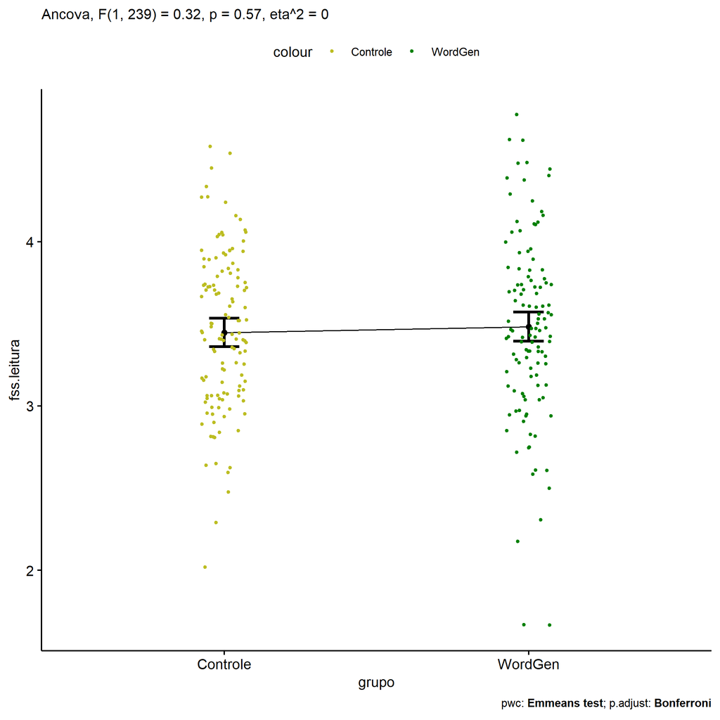

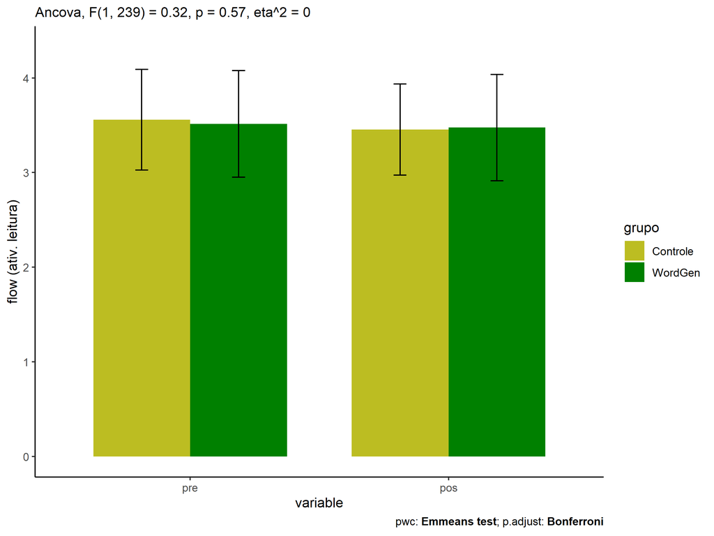

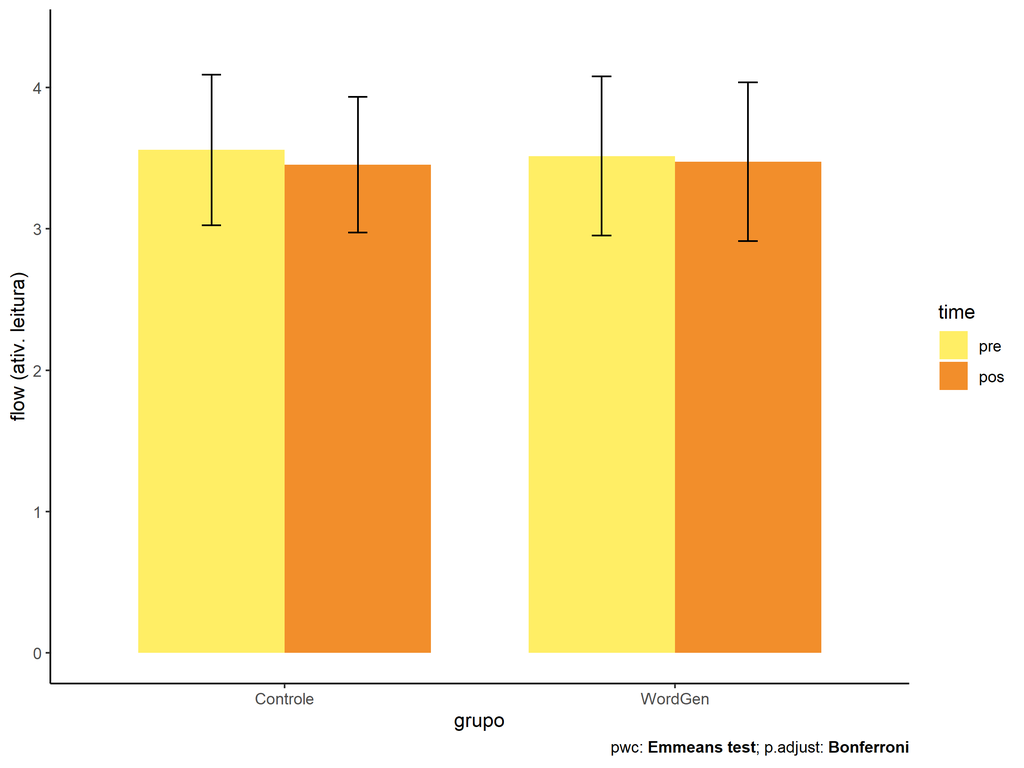

### factor: **genero**

| var | genero | n | M (pre) | SE (pre) | M (unadj) | SE (unadj) | M (adj) | SE (adj) |
| --- | --- | --- | --- | --- | --- | --- | --- | --- |
| fss.leitura | F | 113 | 3.616 | 0.049 | 3.587 | 0.044 | 3.563 | 0.045 |
| fss.leitura | M | 129 | 3.468 | 0.050 | 3.357 | 0.047 | 3.378 | 0.042 |

| .y. | group1 | group2 | estimate | conf.low | conf.high | se | statistic | p | p.adj | p.adj.signif |
| --- | --- | --- | --- | --- | --- | --- | --- | --- | --- | --- |
| fss.leitura | F | M | 0.185 | 0.062 | 0.308 | 0.062 | 2.960 | 0.003 | 0.003 | ** |
| dfs.leitura | F | M | 0.148 | 0.010 | 0.286 | 0.070 | 2.119 | 0.035 | 0.035 | * |

| .y. | genero | group1 | group2 | estimate | conf.low | conf.high | se | statistic | p | p.adj | p.adj.signif |
| --- | --- | --- | --- | --- | --- | --- | --- | --- | --- | --- | --- |
| flow.leitura | F | pre | pos | 0.029 | -0.109 | 0.166 | 0.070 | 0.410 | 0.682 | 0.682 | ns |
| flow.leitura | M | pre | pos | 0.111 | -0.017 | 0.240 | 0.065 | 1.699 | 0.090 | 0.090 | ns |

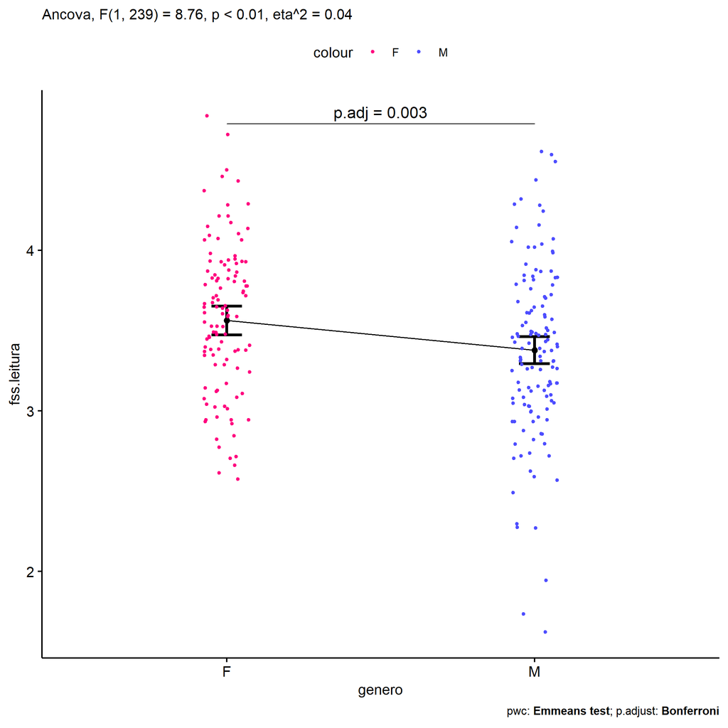

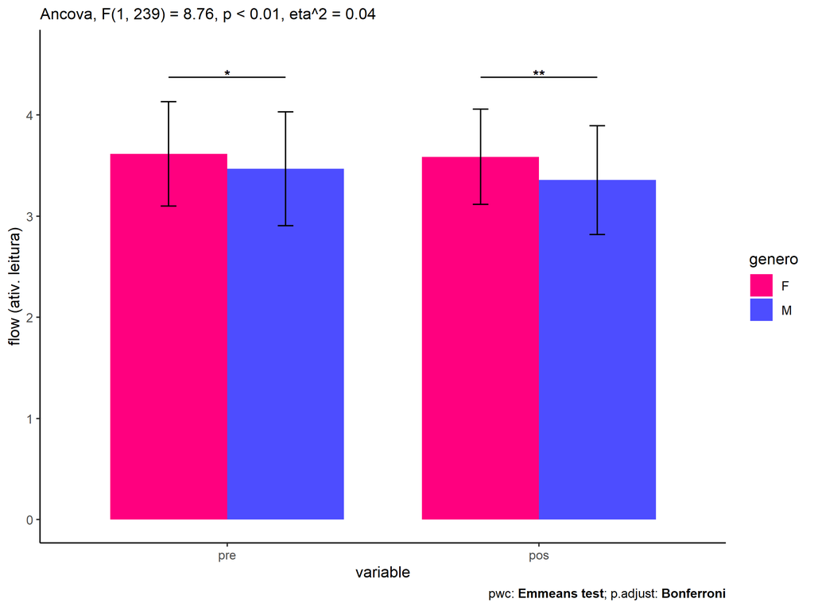

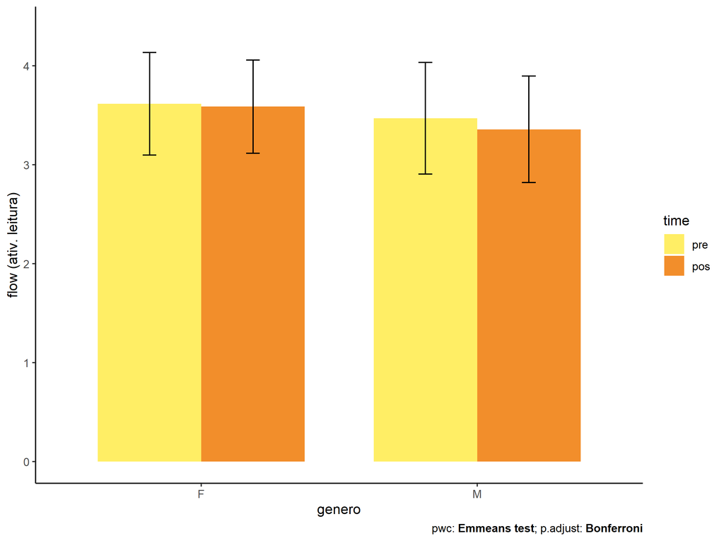

### factor: **idade**

| var | idade | n | M (pre) | SE (pre) | M (unadj) | SE (unadj) | M (adj) | SE (adj) |
| --- | --- | --- | --- | --- | --- | --- | --- | --- |
| fss.leitura | 10y | 47 | 3.493 | 0.078 | 3.460 | 0.075 | 3.482 | 0.071 |
| fss.leitura | 11y | 138 | 3.610 | 0.043 | 3.524 | 0.044 | 3.507 | 0.041 |
| fss.leitura | 12y | 32 | 3.518 | 0.112 | 3.432 | 0.094 | 3.445 | 0.086 |
| fss.leitura | 13y | 13 | 3.338 | 0.147 | 3.084 | 0.121 | 3.156 | 0.135 |

| .y. | group1 | group2 | estimate | conf.low | conf.high | se | statistic | p | p.adj | p.adj.signif |
| --- | --- | --- | --- | --- | --- | --- | --- | --- | --- | --- |
| fss.leitura | 10y | 11y | -0.025 | -0.187 | 0.137 | 0.082 | -0.301 | 0.763 | 1.000 | ns |
| fss.leitura | 10y | 12y | 0.037 | -0.182 | 0.256 | 0.111 | 0.332 | 0.740 | 1.000 | ns |
| fss.leitura | 10y | 13y | 0.325 | 0.026 | 0.625 | 0.152 | 2.139 | 0.034 | 0.201 | ns |
| fss.leitura | 11y | 12y | 0.062 | -0.126 | 0.249 | 0.095 | 0.647 | 0.518 | 1.000 | ns |
| fss.leitura | 11y | 13y | 0.350 | 0.071 | 0.629 | 0.142 | 2.474 | 0.014 | 0.085 | ns |
| fss.leitura | 12y | 13y | 0.288 | -0.026 | 0.603 | 0.160 | 1.806 | 0.072 | 0.433 | ns |
| dfs.leitura | 10y | 11y | -0.118 | -0.294 | 0.058 | 0.089 | -1.316 | 0.189 | 1.000 | ns |
| dfs.leitura | 10y | 12y | -0.025 | -0.264 | 0.213 | 0.121 | -0.210 | 0.834 | 1.000 | ns |
| dfs.leitura | 10y | 13y | 0.155 | -0.172 | 0.482 | 0.166 | 0.935 | 0.351 | 1.000 | ns |
| dfs.leitura | 11y | 12y | 0.092 | -0.112 | 0.297 | 0.104 | 0.888 | 0.376 | 1.000 | ns |
| dfs.leitura | 11y | 13y | 0.273 | -0.030 | 0.575 | 0.153 | 1.777 | 0.077 | 0.462 | ns |
| dfs.leitura | 12y | 13y | 0.180 | -0.162 | 0.523 | 0.174 | 1.037 | 0.301 | 1.000 | ns |

| .y. | idade | group1 | group2 | estimate | conf.low | conf.high | se | statistic | p | p.adj | p.adj.signif |
| --- | --- | --- | --- | --- | --- | --- | --- | --- | --- | --- | --- |
| flow.leitura | 10y | pre | pos | 0.032 | -0.179 | 0.243 | 0.108 | 0.300 | 0.765 | 0.765 | ns |
| flow.leitura | 11y | pre | pos | 0.087 | -0.037 | 0.210 | 0.063 | 1.380 | 0.168 | 0.168 | ns |
| flow.leitura | 12y | pre | pos | 0.086 | -0.170 | 0.342 | 0.130 | 0.662 | 0.509 | 0.509 | ns |
| flow.leitura | 13y | pre | pos | 0.253 | -0.148 | 0.655 | 0.204 | 1.239 | 0.216 | 0.216 | ns |

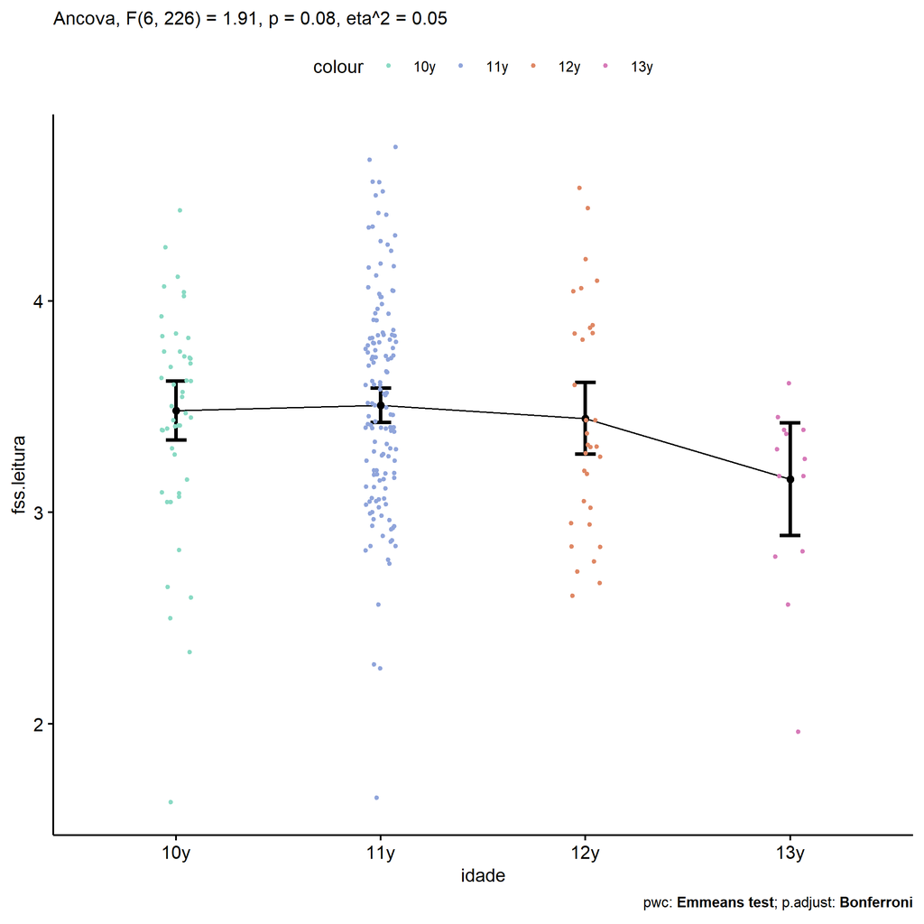

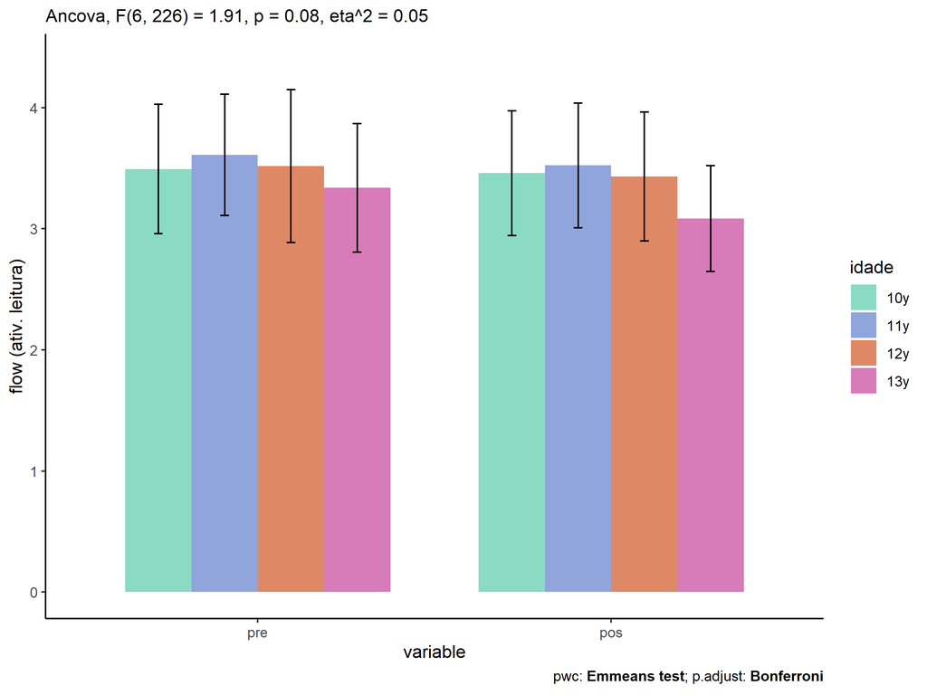

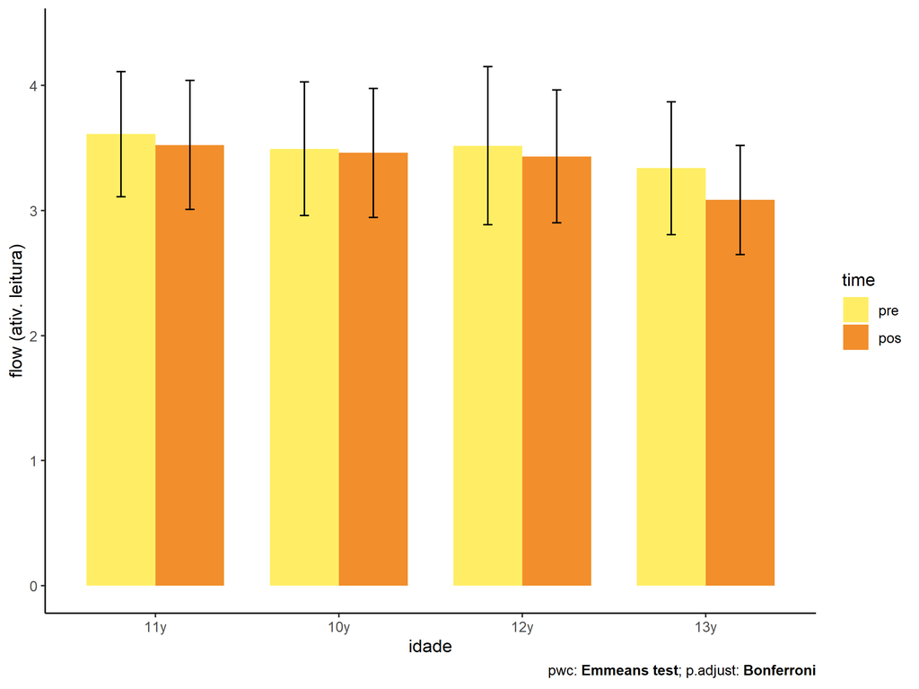

### factor: **zona.participante**

| var | zona.participante | n | M (pre) | SE (pre) | M (unadj) | SE (unadj) | M (adj) | SE (adj) |
| --- | --- | --- | --- | --- | --- | --- | --- | --- |
| fss.leitura | Rural | 91 | 3.537 | 0.055 | 3.41 | 0.059 | 3.404 | 0.052 |
| fss.leitura | Urbana | 98 | 3.498 | 0.061 | 3.47 | 0.047 | 3.476 | 0.050 |

| .y. | group1 | group2 | estimate | conf.low | conf.high | se | statistic | p | p.adj | p.adj.signif |
| --- | --- | --- | --- | --- | --- | --- | --- | --- | --- | --- |
| fss.leitura | Urbana | Rural | 0.072 | -0.070 | 0.213 | 0.072 | 1.001 | 0.318 | 0.318 | ns |
| dfs.leitura | Urbana | Rural | -0.039 | -0.201 | 0.124 | 0.082 | -0.471 | 0.638 | 0.638 | ns |

| .y. | zona.participante | group1 | group2 | estimate | conf.low | conf.high | se | statistic | p | p.adj | p.adj.signif |
| --- | --- | --- | --- | --- | --- | --- | --- | --- | --- | --- | --- |
| flow.leitura | Urbana | pre | pos | 0.027 | -0.125 | 0.180 | 0.077 | 0.352 | 0.725 | 0.725 | ns |
| flow.leitura | Rural | pre | pos | 0.126 | -0.032 | 0.284 | 0.080 | 1.573 | 0.117 | 0.117 | ns |

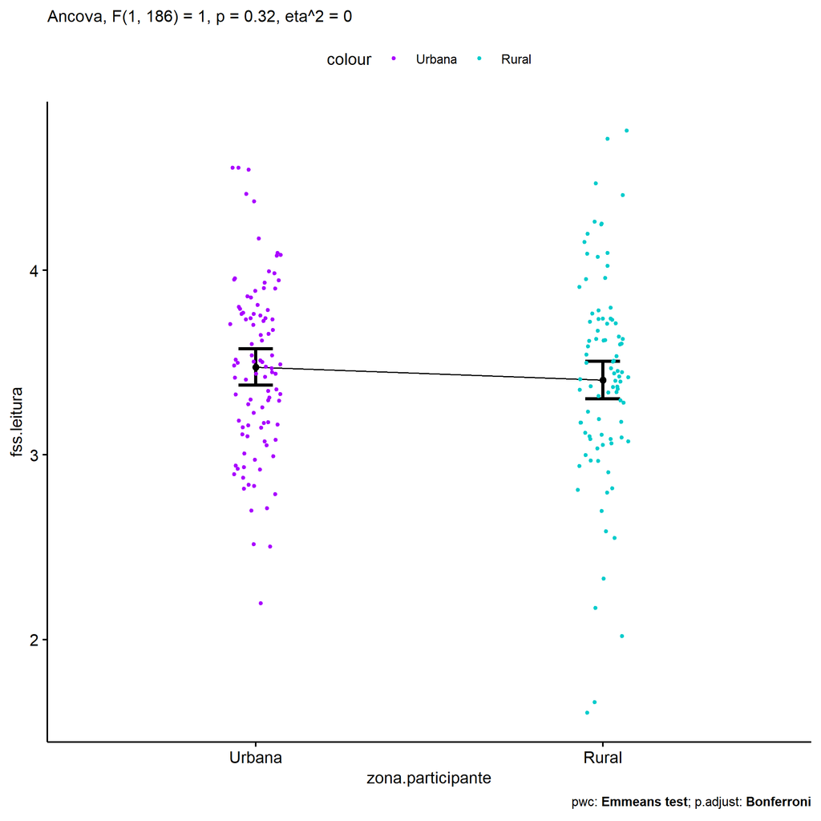

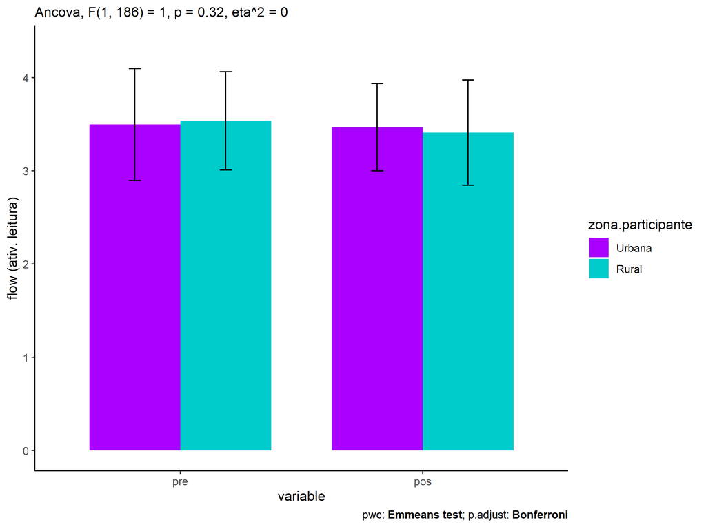

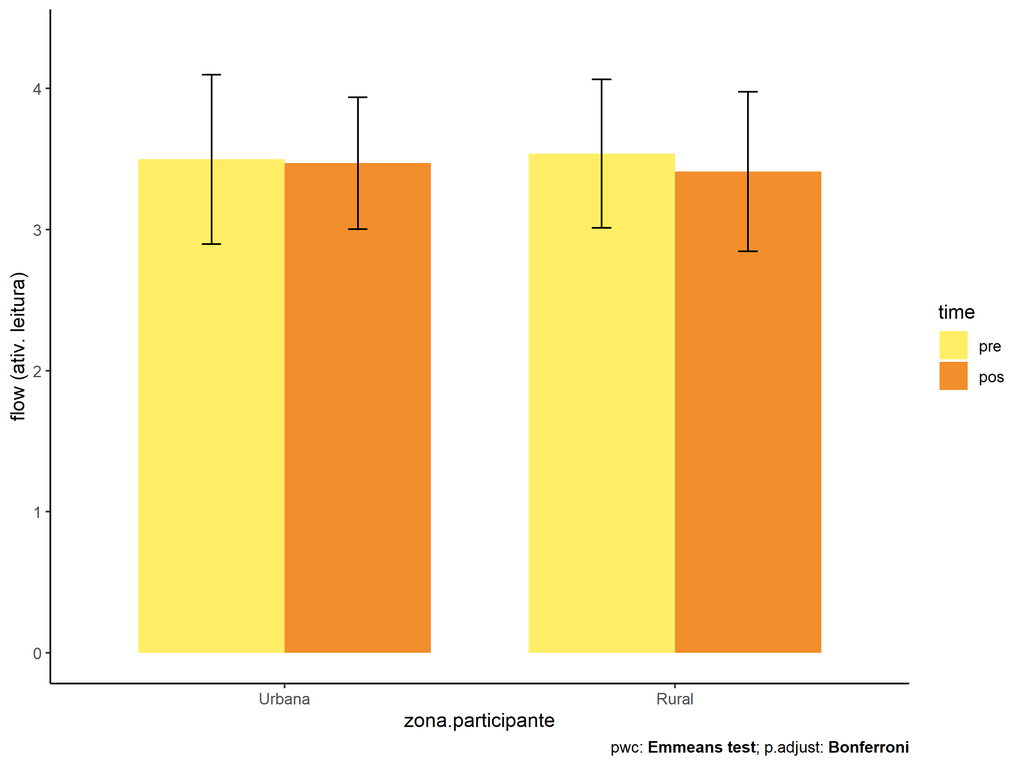

### factor: **escola**

| var | escola | n | M (pre) | SE (pre) | M (unadj) | SE (unadj) | M (adj) | SE (adj) |
| --- | --- | --- | --- | --- | --- | --- | --- | --- |
| fss.leitura | E1 | 22 | 3.196 | 0.133 | 3.574 | 0.127 | 3.701 | 0.104 |
| fss.leitura | E2 | 47 | 3.453 | 0.070 | 3.419 | 0.068 | 3.450 | 0.070 |
| fss.leitura | E3 | 30 | 3.732 | 0.094 | 3.263 | 0.099 | 3.190 | 0.088 |
| fss.leitura | E4 | 25 | 3.620 | 0.088 | 3.506 | 0.093 | 3.475 | 0.096 |
| fss.leitura | E5 | 96 | 3.518 | 0.059 | 3.478 | 0.055 | 3.485 | 0.049 |
| fss.leitura | E6 | 22 | 3.780 | 0.082 | 3.621 | 0.100 | 3.530 | 0.103 |

| .y. | group1 | group2 | estimate | conf.low | conf.high | se | statistic | p | p.adj | p.adj.signif |
| --- | --- | --- | --- | --- | --- | --- | --- | --- | --- | --- |
| fss.leitura | E1 | E2 | 0.251 | 0.006 | 0.496 | 0.124 | 2.021 | 0.044 | 0.666 | ns |
| fss.leitura | E1 | E3 | 0.512 | 0.241 | 0.783 | 0.138 | 3.721 | <0.001 | 0.004 | ** |
| fss.leitura | E1 | E4 | 0.227 | -0.052 | 0.506 | 0.142 | 1.601 | 0.111 | 1.000 | ns |
| fss.leitura | E1 | E5 | 0.216 | -0.009 | 0.441 | 0.114 | 1.890 | 0.06 | 0.901 | ns |
| fss.leitura | E1 | E6 | 0.171 | -0.120 | 0.463 | 0.148 | 1.159 | 0.248 | 1.000 | ns |
| fss.leitura | E2 | E3 | 0.261 | 0.039 | 0.483 | 0.113 | 2.315 | 0.021 | 0.322 | ns |
| fss.leitura | E2 | E4 | -0.024 | -0.258 | 0.209 | 0.119 | -0.204 | 0.839 | 1.000 | ns |
| fss.leitura | E2 | E5 | -0.035 | -0.202 | 0.133 | 0.085 | -0.410 | 0.682 | 1.000 | ns |
| fss.leitura | E2 | E6 | -0.080 | -0.325 | 0.166 | 0.125 | -0.639 | 0.524 | 1.000 | ns |
| fss.leitura | E3 | E4 | -0.285 | -0.540 | -0.030 | 0.129 | -2.203 | 0.029 | 0.429 | ns |
| fss.leitura | E3 | E5 | -0.296 | -0.494 | -0.098 | 0.101 | -2.940 | 0.004 | 0.054 | ns |
| fss.leitura | E3 | E6 | -0.341 | -0.605 | -0.077 | 0.134 | -2.542 | 0.012 | 0.175 | ns |
| fss.leitura | E4 | E5 | -0.011 | -0.222 | 0.201 | 0.107 | -0.100 | 0.92 | 1.000 | ns |
| fss.leitura | E4 | E6 | -0.056 | -0.331 | 0.220 | 0.140 | -0.397 | 0.692 | 1.000 | ns |
| fss.leitura | E5 | E6 | -0.045 | -0.269 | 0.180 | 0.114 | -0.393 | 0.695 | 1.000 | ns |
| dfs.leitura | E1 | E2 | -0.258 | -0.528 | 0.012 | 0.137 | -1.881 | 0.061 | 0.918 | ns |
| dfs.leitura | E1 | E3 | -0.536 | -0.830 | -0.243 | 0.149 | -3.602 | <0.001 | 0.006 | ** |
| dfs.leitura | E1 | E4 | -0.424 | -0.730 | -0.119 | 0.155 | -2.736 | 0.007 | 0.101 | ns |
| dfs.leitura | E1 | E5 | -0.323 | -0.570 | -0.076 | 0.125 | -2.574 | 0.011 | 0.160 | ns |
| dfs.leitura | E1 | E6 | -0.585 | -0.900 | -0.270 | 0.160 | -3.656 | <0.001 | 0.005 | ** |
| dfs.leitura | E2 | E3 | -0.279 | -0.523 | -0.034 | 0.124 | -2.248 | 0.026 | 0.383 | ns |
| dfs.leitura | E2 | E4 | -0.166 | -0.425 | 0.092 | 0.131 | -1.267 | 0.206 | 1.000 | ns |
| dfs.leitura | E2 | E5 | -0.065 | -0.251 | 0.121 | 0.094 | -0.688 | 0.492 | 1.000 | ns |
| dfs.leitura | E2 | E6 | -0.327 | -0.597 | -0.057 | 0.137 | -2.386 | 0.018 | 0.267 | ns |
| dfs.leitura | E3 | E4 | 0.112 | -0.171 | 0.395 | 0.144 | 0.781 | 0.436 | 1.000 | ns |
| dfs.leitura | E3 | E5 | 0.214 | -0.005 | 0.432 | 0.111 | 1.925 | 0.055 | 0.831 | ns |
| dfs.leitura | E3 | E6 | -0.048 | -0.342 | 0.245 | 0.149 | -0.325 | 0.746 | 1.000 | ns |
| dfs.leitura | E4 | E5 | 0.101 | -0.133 | 0.336 | 0.119 | 0.851 | 0.395 | 1.000 | ns |
| dfs.leitura | E4 | E6 | -0.161 | -0.466 | 0.145 | 0.155 | -1.035 | 0.302 | 1.000 | ns |
| dfs.leitura | E5 | E6 | -0.262 | -0.509 | -0.015 | 0.125 | -2.089 | 0.038 | 0.567 | ns |

| .y. | escola | group1 | group2 | estimate | conf.low | conf.high | se | statistic | p | p.adj | p.adj.signif |
| --- | --- | --- | --- | --- | --- | --- | --- | --- | --- | --- | --- |
| flow.leitura | E1 | pre | pos | -0.378 | -0.688 | -0.068 | 0.158 | -2.395 | 0.017 | 0.017 | * |
| flow.leitura | E2 | pre | pos | 0.034 | -0.178 | 0.246 | 0.108 | 0.318 | 0.751 | 0.751 | ns |
| flow.leitura | E3 | pre | pos | 0.469 | 0.204 | 0.735 | 0.135 | 3.474 | <0.001 | <0.001 | *** |
| flow.leitura | E4 | pre | pos | 0.114 | -0.177 | 0.405 | 0.148 | 0.772 | 0.441 | 0.441 | ns |
| flow.leitura | E5 | pre | pos | 0.040 | -0.108 | 0.188 | 0.076 | 0.530 | 0.596 | 0.596 | ns |
| flow.leitura | E6 | pre | pos | 0.159 | -0.151 | 0.469 | 0.158 | 1.008 | 0.314 | 0.314 | ns |

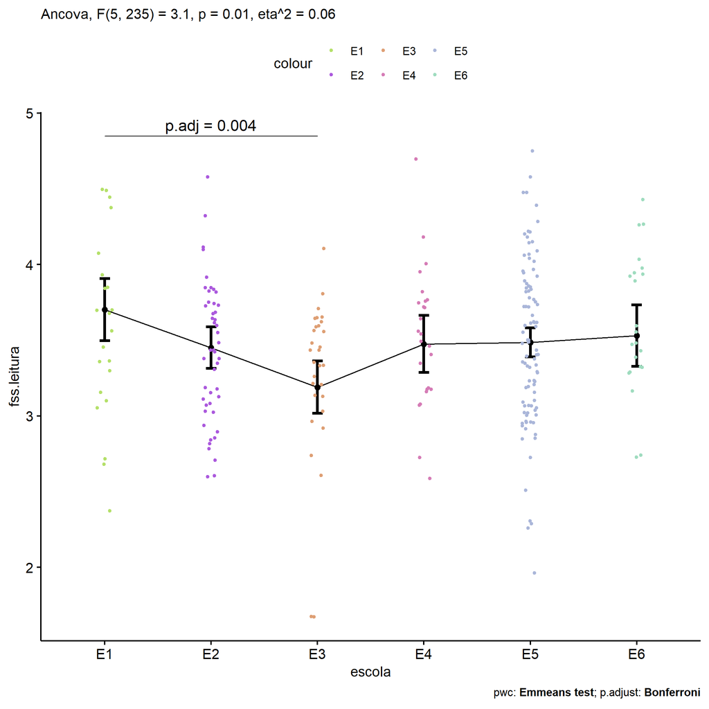

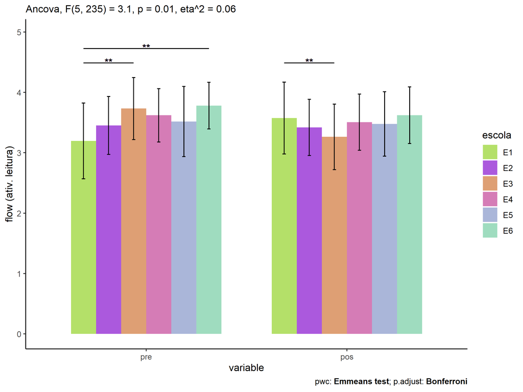

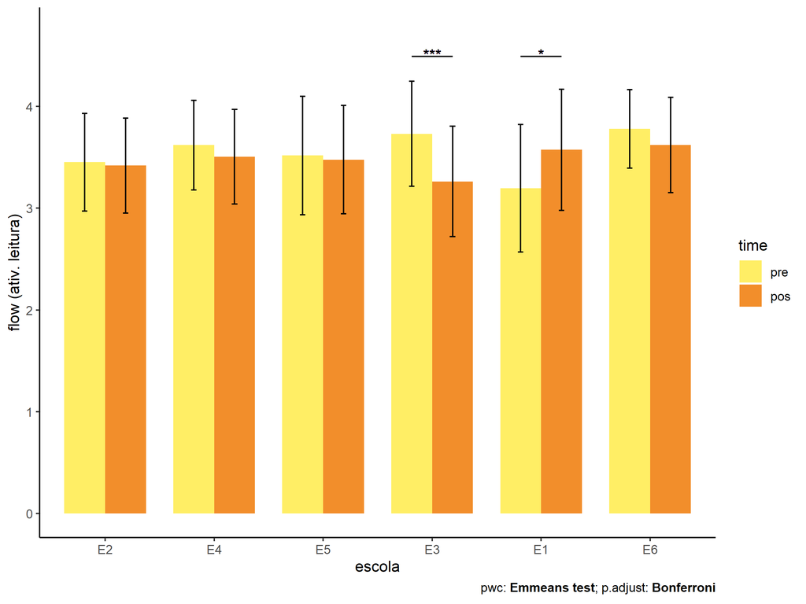

### factor: **zona.escola**

| var | zona.escola | n | M (pre) | SE (pre) | M (unadj) | SE (unadj) | M (adj) | SE (adj) |
| --- | --- | --- | --- | --- | --- | --- | --- | --- |
| fss.leitura | Rural | 77 | 3.709 | 0.052 | 3.444 | 0.059 | 3.383 | 0.056 |
| fss.leitura | Urbana | 165 | 3.457 | 0.044 | 3.474 | 0.041 | 3.503 | 0.038 |

| .y. | group1 | group2 | estimate | conf.low | conf.high | se | statistic | p | p.adj | p.adj.signif |
| --- | --- | --- | --- | --- | --- | --- | --- | --- | --- | --- |
| fss.leitura | Urbana | Rural | 0.120 | -0.015 | 0.255 | 0.069 | 1.747 | 0.082 | 0.082 | ns |
| dfs.leitura | Urbana | Rural | -0.253 | -0.398 | -0.107 | 0.074 | -3.423 | <0.001 | <0.001 | *** |

| .y. | zona.escola | group1 | group2 | estimate | conf.low | conf.high | se | statistic | p | p.adj | p.adj.signif |
| --- | --- | --- | --- | --- | --- | --- | --- | --- | --- | --- | --- |
| flow.leitura | Urbana | pre | pos | -0.017 | -0.131 | 0.097 | 0.058 | -0.299 | 0.765 | 0.765 | ns |
| flow.leitura | Rural | pre | pos | 0.265 | 0.098 | 0.433 | 0.085 | 3.122 | 0.002 | 0.002 | ** |

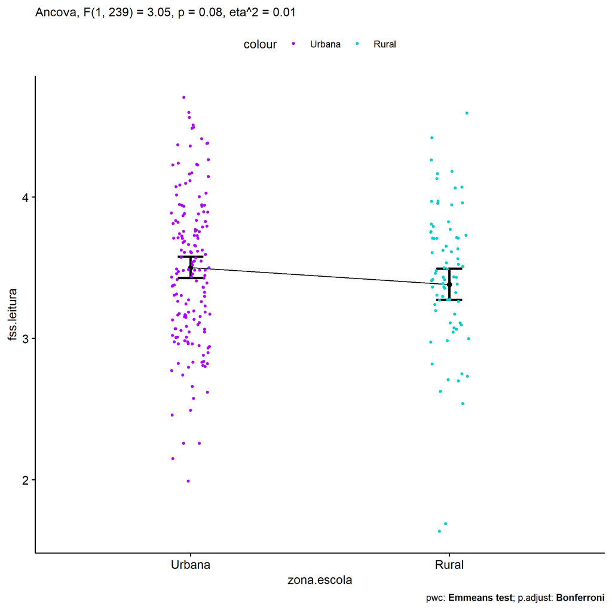

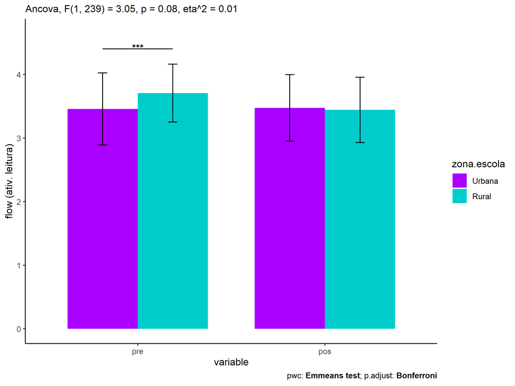

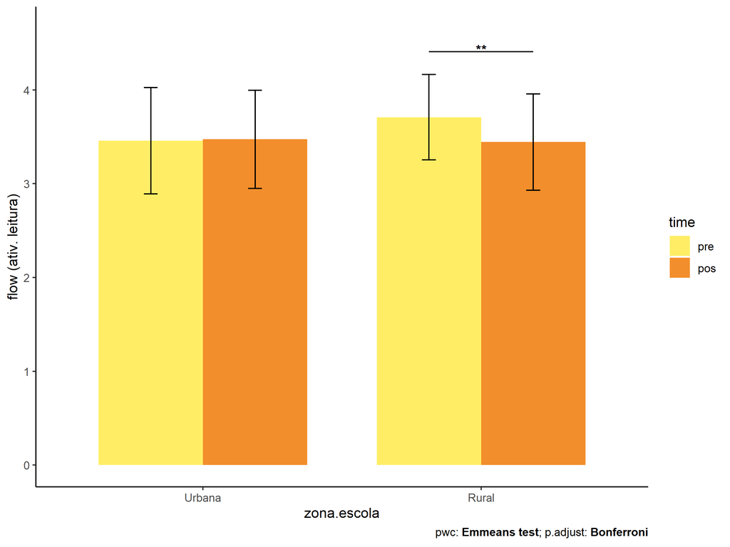